# One_Shot_Learning

This notebook tries to classify [Singapore Botanic Garden plant images](https://github.com/vinayprabhu/Singapore_botanic_gardens/blob/master/Dataset.zip) using One shot learning.

This notebook uses a deep convolutional neural network (CNN) to extract features from input images. [Keras](https://keras.io/) is used for implementing the CNN.

## One shot learning

One of the main requisites of highly accurate deep learning models is large amount of data. The set of hyperparameters a Deep Model need to be tuned are very large, and the amount of data needed to get the right set of value for these hyperparameters is also large.

But what if we need an automated system, which can successfully classify images to various classes given the data for each image class is quite less.

**One shot learning** is such a problem. We can **One shot learning** as a problem to classify data into K classes where each class has only few examples. The paper written by [Gregory et. al](http://www.cs.utoronto.ca/~gkoch/files/msc-thesis.pdf), suggest ideas for building a Neural Network Architecture to solve this problem.

One particularly interesting task is classification under the restriction that we may only observe a single example of each possible class before making a prediction about a test instance. This is called one-shot learning and it is the primary focus of our model presented in this work.

> **Note:** Code and Markdown cells can be executed using the **Shift + Enter** keyboard shortcut. In addition, Markdown cells can be edited by typically double-clicking the cell to enter edit mode.

# Import libraries

```python
import cv2
import sys
import pytesseract
import glob
import pandas as pd
import matplotlib.pyplot as plt
import pickle
import matplotlib.image as mping
from math import *
import os
import shutil
import numpy as np
from PIL import Image
from keras.preprocessing.image import ImageDataGenerator, array_to_img, img_to_array, load_img
# Import Keras and other Deep Learning dependencies
from keras.models import Sequential
from keras.callbacks import EarlyStopping
from keras.layers import Convolution2D, MaxPooling2D, Flatten
from keras.layers.core import Dense, Dropout, Activation
from keras.optimizers import RMSprop
import time
from keras.optimizers import Adam
from keras.layers import Conv2D, ZeroPadding2D, Activation, Input, concatenate, MaxPool2D, Flatten, Dense, Subtract, Lambda
from keras.models import Model
import seaborn as sns
from keras.layers.normalization import BatchNormalization
from keras.layers.pooling import MaxPooling2D, AveragePooling2D
from keras.layers.merge import Concatenate
from keras.layers.core import Lambda, Flatten, Dense
from keras.initializers import glorot_uniform
from sklearn.preprocessing import LabelBinarizer
from keras.optimizers import *
from keras.engine.topology import Layer
from keras import backend as K
from keras.regularizers import l2
from keras.callbacks import Callback, ModelCheckpoint
from sklearn.metrics import accuracy_score,confusion_matrix, f1_score, precision_score, recall_score
import random
from data_loader import *
from utils import *
import zipfile
import wget

K.set_image_data_format('channels_last')
%matplotlib inline
```

# Helper Functions

```python
def unzipFiles(fileName, outputFolder="."):
    """
    Unzip folder/file.
    """
    zipfilePath = (fileName)
    zip = zipfile.ZipFile(zipfilePath)
    zip.extractall(outputFolder)
    zip.close()
    print("Unzipping the folder {}".format(fileName))


def downloadFile(s3Path, localPath):
    """
    Download file from url
    """
    print('Downloading file from {} ..'.format(s3Path))

    url = s3Path
    wget.download(url, localPath)
    print("File downloaded on {}".format(localPath))
```

## Download dataset:

https://github.com/vinayprabhu/Singapore_botanic_gardens/blob/master/Dataset.zip

```python
def extractTextFromImage():
    labelingDictn = {}
    cnt = 0
    for filepath in glob.iglob('new_train/*'):
        # Define config parameters.
        # '-l eng'  for using the English language
        # '--oem 1' for using LSTM OCR Engine
        print(filepath)
        config = ('-l eng --oem 1 --psm 3')

        # Read image from disk
        im = cv2.imread(filepath, cv2.IMREAD_COLOR)

        # Run tesseract OCR on image
        text = pytesseract.image_to_string(im, config=config)

        labelingDictn[filepath] = text

    return labelingDictn
```

# Image Processing

```python
# Loading calibration values
mtx, dist, rvecs, tvecs = pickle.load( open('./calibrations.pickle', 'rb' ))
```

# Display Images

```python
def showImages(images, cols = 3, figsize=(25,25), colorspace='rgb', showOriginal=False):
    """
    Display `images` on a [`cols`, `rows`] subplot grid.
    """
    num_images = len(images)
    rows = (num_images//cols)
    fig, axes = plt.subplots(rows, cols, figsize=figsize)
    indexes = range(cols * rows)
    for ax, index in zip(axes.flat, indexes):
        if index < num_images:
            imagePathName, img = images[index]
            if len(img.shape) == 3:
                # color space conversion
                if colorspace == 'gray':
                    img = cv2.cvtColor(img, cv2.COLOR_BGR2GRAY)
                elif colorspace == 'hsv':
                    img = cv2.cvtColor(img, cv2.COLOR_BGR2HSV)
                elif colorspace == 'hls':
                    img = cv2.cvtColor(img, cv2.COLOR_BGR2HLS)
                elif colorspace == 'lab':
                    img = cv2.cvtColor(img, cv2.COLOR_BGR2LAB)
                elif colorspace == 'luv':
                    img = cv2.cvtColor(img, cv2.COLOR_BGR2LUV)
                elif colorspace == 'yuv':
                    img = cv2.cvtColor(img, cv2.COLOR_BGR2YUV)
                else:
                    img = cv2.cvtColor(img, cv2.COLOR_BGR2RGB)

            if showOriginal:
                ax.imshow(img)
            else:
                ax.imshow(img, cmap='gray')
            ax.set_title(imagePathName.split('/')[-1])
            ax.set_xticks([], minor=False)
            ax.set_yticks([], minor=False)
```

## Data folder Preparation

```python
### Data Folders Path

training_dir = "./data/training/"
testing_dir = "./data/testing/"

if not os.path.isdir(training_dir):
    os.makedirs(training_dir)

if not os.path.isdir(testing_dir):
    os.makedirs(testing_dir)
```

```python
# Downloading test data from s3 and unzip it.

## Preparing training data
if not os.path.exists('train.zip'):
    downloadFile('https://s3.amazonaws.com/interview-question/Unifyid/train.zip', '.')
    unzipFiles('train.zip')

## Preparing testing data
if not os.path.exists('test.zip'):
    downloadFile('https://s3.amazonaws.com/interview-question/Unifyid/test.zip', '.')
    unzipFiles('test.zip')
```

## Let's visualize our data

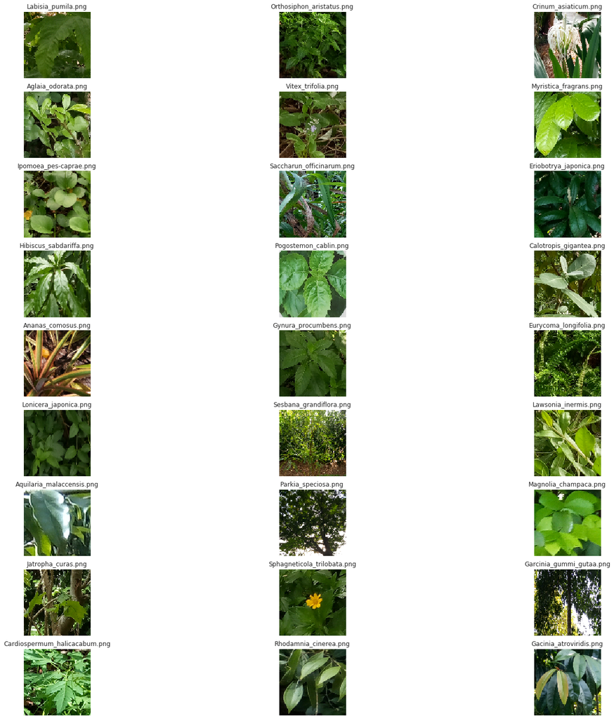

```python
# Load test images.
trainImages = list(map(lambda imageFileName: (imageFileName, cv2.imread(imageFileName)),
                      glob.iglob('train/*/*.png')))
showImages(trainImages, showOriginal=True)
```

# Resizing image

```python
def resizingImage(img):
    """
    Convert each image into 100*100 size.
    """
    res = cv2.resize(img, (100, 100), interpolation = cv2.INTER_CUBIC)
    return res
```

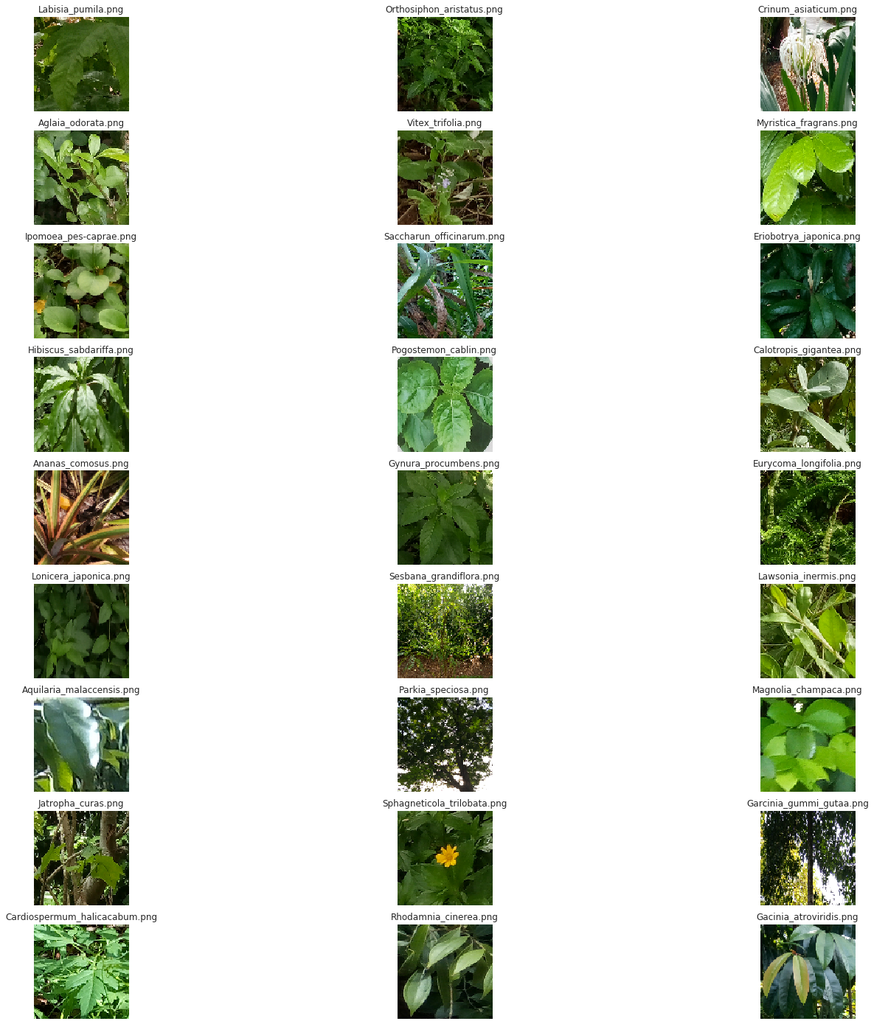

```python
resized_train_images = list(map(lambda image: (image[0], resizingImage(image[1])), trainImages))
showImages(resized_train_images)
```

# Undistort Images

```python
def imgUndistort(img, mtx=mtx, dist=dist):
    """
    Undistort image

    Arguments:
        img: source image
        mtx: camera internal matrix
        dist: distortion coefficients
    """
    return cv2.undistort(img, mtx, dist, None, mtx)
```

```python
def makeBinaryImage(img, mag_threshold=(0,255), dir_threshold=(0.7, 1.3), mode='simple', sobel_kernel=3):
    '''
    Returns a binary image based on the following inputs
    - threshold
    - threshold mode
    '''
    binary = np.zeros_like(img)
    if mode == 'sobelX':
        sobelX_abs = np.absolute(cv2.Sobel(img, cv2.CV_64F, 1, 0, ksize=sobel_kernel))
        scaled_sobelX = np.uint8(255*sobelX_abs/np.max(sobelX_abs))
        binary[(scaled_sobelX >= mag_threshold[0]) & (scaled_sobelX <= mag_threshold[1])] = 1
    elif mode == 'sobelY':
        sobelY_abs = np.absolute(cv2.Sobel(img, cv2.CV_64F, 0, 1, ksize=sobel_kernel))
        scaled_sobelY = np.uint8(255*sobelY_abs/np.max(sobelY_abs))
        binary[(scaled_sobelY >= mag_threshold[0]) & (scaled_sobelY <= mag_threshold[1])] = 1
    elif mode == 'magnitude':
        sobelX = cv2.Sobel(img, cv2.CV_64F, 1, 0, ksize=sobel_kernel)
        sobelY = cv2.Sobel(img, cv2.CV_64F, 0, 1, ksize=sobel_kernel)
        # calculate the magnitude
        sobel_mag = np.sqrt(np.square(sobelX) + np.square(sobelY))
        # scale to 8-bit (0 - 255) and convert to type = np.uint8
        sobel_scale = np.uint8(255*sobel_mag/np.max(sobel_mag))
        # create a binary mask where mag thresholds are met
        binary[(sobel_scale >= mag_threshold[0]) & (sobel_scale <= mag_threshold[1])] = 1
    elif mode == 'direction':
        sobelX_abs = np.absolute(cv2.Sobel(img, cv2.CV_64F, 1, 0, ksize=sobel_kernel))
        scaled_sobelX = np.uint8(255*sobelX_abs/np.max(sobelX_abs))
        sobelY_abs = np.absolute(cv2.Sobel(img, cv2.CV_64F, 0, 1, ksize=sobel_kernel))
        scaled_sobelY = np.uint8(255*sobelY_abs/np.max(sobelY_abs))
        # use np.arctan2(abs_sobely, abs_sobelx) to calculate the direction of the gradient
        gradients = np.arctan2(scaled_sobelY, scaled_sobelX)
        binary[(gradients >= dir_threshold[0]) & (gradients <= dir_threshold[1])] = 1
    elif mode == 'mag_dir_combined':
        # Take the gradient in x and y separately
        sobelx = cv2.Sobel(img, cv2.CV_64F, 1, 0, ksize=9)
        sobely = cv2.Sobel(img, cv2.CV_64F, 0, 1, ksize=9)

        # Calculate the magnitude of gradient
        gradmag = np.sqrt(sobelx**2 + sobely**2)

        # Scale to 8-bit (0 - 255) and convert to type = np.uint8
        scaled_sobel = np.uint8(255*gradmag / np.max(gradmag))

        #Calculate angle
        abs_sobelx = np.absolute(sobelx)
        abs_sobely = np.absolute(sobely)
        absgraddir = np.arctan2(abs_sobely, abs_sobelx)

        # Create a binary mask where mag thresholds are met
        binary = np.zeros_like(scaled_sobel)
        binary[(scaled_sobel >= mag_threshold[0]) & \
                      (scaled_sobel <= mag_threshold[1]) & \
                      (absgraddir >= dir_threshold[0])   & \
                      (absgraddir <= dir_threshold[1])] = 1
    elif mode == 'mag_color_combined':
        sx_thresh=(20, 50)
        s_thresh=(170, 255)
        l_thresh=(40, 255)
        # Convert to HLS color space and separate the L and S
        hls = cv2.cvtColor(img, cv2.COLOR_RGB2HLS)
        l_channel = hls[:,:,1]
        s_channel = hls[:,:,2]
        # Sobel x
        sobelx = cv2.Sobel(l_channel, cv2.CV_64F, 1, 0) # Take the derivative in x
        abs_sobelx = np.absolute(sobelx) # Absolute x derivative to accentuate lines away from horizontal
        scaled_sobel = np.uint8(255*abs_sobelx/np.max(abs_sobelx))

        # Threshold x gradient
        sxbinary = np.zeros_like(scaled_sobel)
        sxbinary[(scaled_sobel >= sx_thresh[0]) & (scaled_sobel <= sx_thresh[1])] = 1

        # Threshold color channel
        s_binary = np.zeros_like(s_channel)
        s_binary[(s_channel >= s_thresh[0]) & (s_channel <= s_thresh[1])] = 1

        # Threshold lightness
        l_binary = np.zeros_like(l_channel)
        l_binary[(l_channel >= l_thresh[0]) & (l_channel <= l_thresh[1])] = 1

        # Stack each channel
        channels = 255*np.dstack(( l_binary, sxbinary, s_binary)).astype('uint8')
        binary = np.zeros_like(sxbinary)
        binary[((l_binary == 1) & (s_binary == 1) | (sxbinary==1))] = 1
        binary = 255*np.dstack((binary,binary,binary)).astype('uint8')
    elif mode == 'hls_s_channel':
        hls = cv2.cvtColor(img, cv2.COLOR_RGB2HLS)
        s_channel = hls[:,:,2]
        binary[(s_channel > mag_threshold[0]) & (s_channel <= mag_threshold[1])] = 1
    elif mode == 'laplacian_s_channel_combined':
        hls = cv2.cvtColor(img.astype(np.uint8), cv2.COLOR_RGB2HLS)
        gray = (0.5*img[:,:,0] + 0.4*img[:,:,1] + 0.1*img[:,:,2]).astype(np.uint8)
        s = hls[:,:,2]

        _, gray_binary = cv2.threshold(gray.astype('uint8'), 150, 255, cv2.THRESH_BINARY)

        total_px = img.shape[0]*img.shape[1]
        laplacian = cv2.Laplacian(gray, cv2.CV_32F, ksize=21)
        mask_three = (laplacian < 0.15*np.min(laplacian)).astype(np.uint8)
        if cv2.countNonZero(mask_three)/total_px < 0.01:
            laplacian = cv2.Laplacian(gray, cv2.CV_32F, ksize=21)
            mask_three = (laplacian < 0.075*np.min(laplacian)).astype(np.uint8)

        _, s_binary = cv2.threshold(s.astype('uint8'), 150, 255, cv2.THRESH_BINARY)
        mask_two = s_binary

        binary = np.clip(cv2.bitwise_and(gray_binary,
                            cv2.bitwise_or(mask_three, mask_two)), 0, 1).astype('uint8')
        binary[:ceil(img.shape[0]//2)] = 0
    else:
        binary[(img >= mag_threshold[0]) & (img <= mag_threshold[1])] = 1
    return binary
```

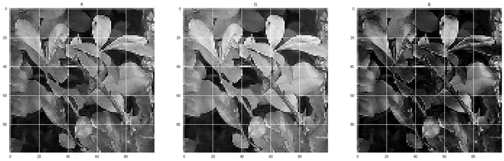

```python
fig, axes = plt.subplots(ncols=3, figsize=(25,10))
for index, ax in enumerate(axes):
    ax.imshow(cv2.cvtColor(resized_train_images[3][1], cv2.COLOR_BGR2RGB)[:, :, index], cmap='gray')
    ax.set_title(titles[index+1])
```

```python
def applyAndShow(images, mag_threshold=(0,255), dir_threshold=(0.7,1.3), sobel_kernel=3, action='simple'):
    """
    Applies `action` to the pair collection `images` (`title`, image) show the images and titles and return
    (`title`, `action`(image))
    """
    output = list(map(lambda img: (img[0], makeBinaryImage(cv2.cvtColor(img[1], cv2.COLOR_BGR2RGB), mag_threshold, dir_threshold, action, sobel_kernel)), images))
    showImages( output, colorspace='gray')
    return output
```

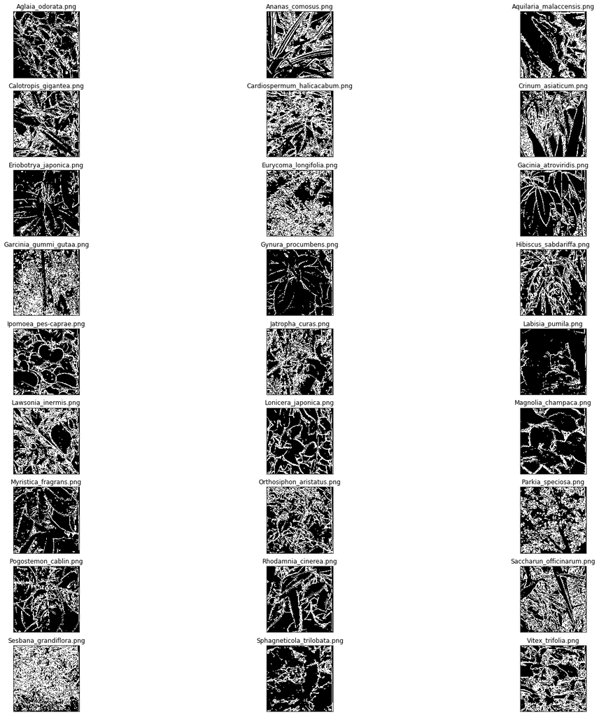

```python
mag_binary_output = applyAndShow(resized_train_images, mag_threshold=(20,100), sobel_kernel=9, action='magnitude')
```

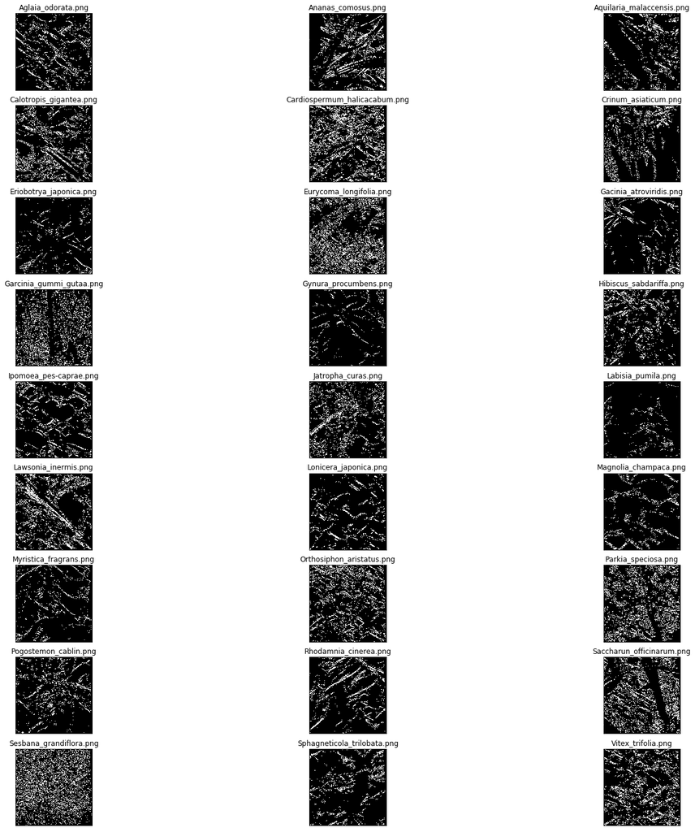

```python
mag_dir_binary_output = applyAndShow(resized_train_images, mag_threshold=(20,150), dir_threshold=(0.7,1.3), action='mag_dir_combined')
```

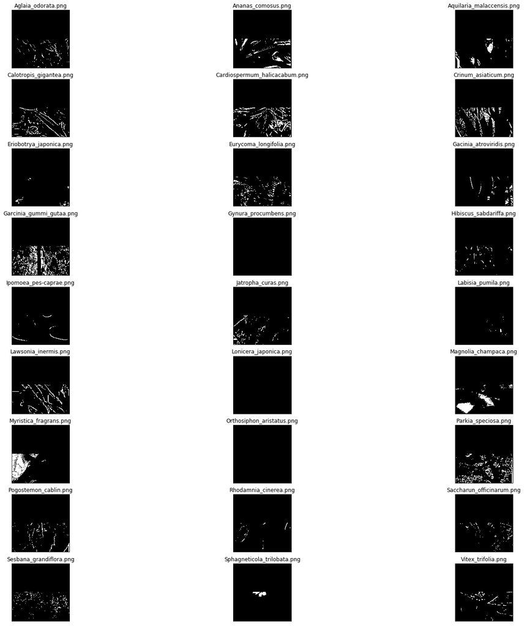

```python
laplacian_binary_output = applyAndShow(resized_train_images, action='laplacian_s_channel_combined')
```

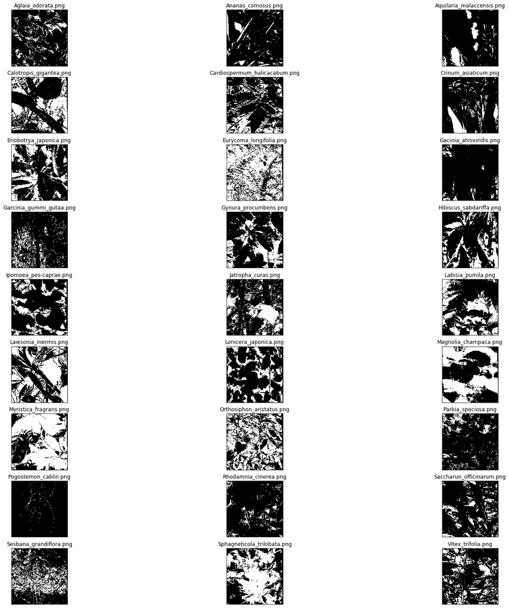

```python
hls_binary_output = applyAndShow(resized_train_images,  mag_threshold=(190,255), action='hls_s_channel')
```

# Generate Test Dataset from Image slicing

```python
def calculate_columns_rows(n):
    """
    Calculate the number of columns and rows required to divide an image
    into 'n' parts.
    """
    num_columns = int(ceil(sqrt(n)))
    num_rows = int(ceil(n / float(num_columns)))
    return (num_columns, num_rows)
```

```python
def image_slicing(filename, number_slices, save=True, deleteOriginalFile=True):
    """
    Split an image into a specified number of slices.
    """
    img = cv2.imread(filename)

    image_h, image_w = img.shape[:2]
    columns, rows = calculate_columns_rows(number_slices)
    extras = (columns * rows) - number_slices
    tile_w, tile_h = int(floor(image_w / columns)), int(floor(image_h / rows))

    sliced_images = []
    for pos_y in range(0, image_h - rows, tile_h): # -rows for rounding error.
        for pos_x in range(0, image_w - columns, tile_w): # same logic as above.
            crop_img = img[pos_y:pos_y+tile_h, pos_x:pos_x+tile_w]
            sliced_images.append(resizingImage(crop_img))

    if save:
        save_slices(filename.split('.')[0].split('/')[1], sliced_images, filename)
    if deleteOriginalFile:
        os.remove(filename)


def save_slices(outFolder, output_images, fileName):
    """
    Write image files to disk. Create specified folder(s) if they
    don't exist.
    """

    if not os.path.exists(os.path.join(testing_dir, outFolder)):
        os.makedirs(os.path.join(testing_dir, outFolder))

    for slice_number, img in enumerate(output_images):
        imgName = fileName.split('.')[0].split('/')[1].lower() + '_' + fileName.split('.')[0].split('/')[2] +'_slice' + str(slice_number) + '.jpg'
        outFile = '{0}/{1}'.format(os.path.join(testing_dir, outFolder), imgName)
        cv2.imwrite(outFile, img)
```

```python
def createTestDataset():
    number_slices_for_each_image = 16
    for each_file in list(glob.iglob('test/*/*.png', recursive=True)):
        image_slicing(each_file, number_slices=number_slices_for_each_image, save=True, deleteOriginalFile=True)

    print("{} slices generated for each image..".format(number_slices_for_each_image))

createTestDataset()
```

```
16 slices generated for each image..
```

# Generating Training dataset

```python
def createTrainDataset():
    """
    Resizing images and augmenting training data with different settings
    """

    # Resize image first
    for filename in glob.iglob('train/*/*.png'):
        img = cv2.imread(filename)
        os.remove(filename) #remove the existing file
        cv2.imwrite(filename, resizingImage(img)) # resize the image and save it


    # Image Augmentation
    train_datagen = ImageDataGenerator(
                        rotation_range=15,
                        width_shift_range=0.1,
                        height_shift_range=0.1,
                        shear_range=0.01,
                        zoom_range=[0.9, 1.5],
                        horizontal_flip=True,
                        vertical_flip=False,
                        fill_mode='reflect',
                        brightness_range=[0.5, 2])


    for filePath in glob.iglob('train/*/*.png'):

        folder = training_dir + filePath.split('/')[1]

        if not os.path.exists(folder):
            os.makedirs(folder)

        img = load_img(filePath)  # this is a PIL image
        x = img_to_array(img)  # this is a Numpy array with shape (3, 400, 400)
        x = x.reshape((1,) + x.shape)  # this is a Numpy array with shape (1, 3, 400, 400)

        # the .flow() command below generates batches of randomly transformed images
        # and saves the results to the respective directory
        i = 0
        for batch in train_datagen.flow(x, batch_size=1,
                                  save_to_dir=folder, save_prefix='file', save_format='png'):
            i += 1
            if i > 20:
                break  # otherwise the generator would loop indefinitely

    print("Image augmentation finished...")



####  start augmentation process...
createTrainDataset()
```

```
Image augmentation finished...
```

```python
# Check whether GPU is being or not
from tensorflow.python.client import device_lib
print(device_lib.list_local_devices())
```

```
[name: "/device:CPU:0"
device_type: "CPU"
memory_limit: 268435456
locality {
}
incarnation: 4569955673450438990
, name: "/device:XLA_CPU:0"
device_type: "XLA_CPU"
memory_limit: 17179869184
locality {
}
incarnation: 13643257494397357231
physical_device_desc: "device: XLA_CPU device"
]
```

## Insights about images after data munging

```python
img = cv2.imread('data/training/Aglaia_odorata/file_0_130.png')
print("Each image in the data set has a same of {0}".format(img.shape))
flattened_img = img.flatten()

print("The number of features in any image from the data set are: {0}".format(flattened_img.shape[0]))
```

```
Each image in the data set has a same of (100, 100, 3)
The number of features in any image from the data set are: 30000
```

## Class labels

```python
def createClassDictionary():
    class_dictn = {}
    for index, class_label in enumerate(os.listdir('data/training/')):
        class_dictn[class_label] = index
    return class_dictn

class_dictn = createClassDictionary()
```

```python
class_dictn.keys()
```

[output not shown]

```python
def make_dataset(dataType):
    X = []
    y = []
    dataFolder = 'data/{}ing/*/*'.format(dataType)
    for each_file in glob.iglob(dataFolder):
        X_current, y_current = cv2.imread(each_file), each_file.split('/')[2]
        X.append(resizingImage(X_current))
        label = class_dictn[y_current]
        y.append(label)

    return np.array(X), np.array(y)
```

```python
X_train, y_train = make_dataset(dataType='train')
X_test, y_test = make_dataset(dataType='test')
```

```python
def writeDataIntoFile(X_train, y_train, X_test, y_test):
    with open(os.path.join(save_path,"train_small.pickle"), "wb") as f:
        pickle.dump((X_train,y_train),f)

    with open(os.path.join(save_path,"val_small.pickle"), "wb") as f:
        pickle.dump((X_test,y_test),f)

writeDataIntoFile(X_train, y_train, X_test, y_test)
```

```python
def load_dataset():
    with open(os.path.join(save_path, "train_small.pickle"), "rb") as f:
        (X_train, y_train) = pickle.load(f)

    with open(os.path.join(save_path, "val_small.pickle"), "rb") as f:
        (X_test, y_test) = pickle.load(f)

    X_train = X_train.astype('float32')
    X_test = X_test.astype('float32')
    X_train /= 255
    X_test /= 255

    return X_train, y_train, X_test, y_test

X_train, y_train, X_test, y_test = load_dataset()
```

```python
print("Total number of training samples: {0} and testing samples: {1}".format(X_train.shape[0], X_test.shape[0]))
```

```
Total number of training samples: 567 and testing samples: 1056
```

## Configurations

```python
num_classes = len(class_dictn.keys())
epochs = 10
learning_rate = 10e-4
# Final layer-wise momentum
momentum = 0.9

# linear epoch slope evolution
momentum_slope = 0.01
support_set_size = 20

# l2-regularization penalization for each layer
l2_penalization = {}
l2_penalization['Conv1'] = 2e-4
l2_penalization['Conv2'] = 2e-4
l2_penalization['Conv3'] = 2e-4
l2_penalization['Conv4'] = 2e-4
l2_penalization['Dense1'] = 1e-3

save_path = 'data/'
```

## Helper functions for model

```python
def euclidean_distance(inputs):
    assert len(inputs) == 2, \
        'Euclidean distance needs 2 inputs, %d given' % len(inputs)
    x, y = inputs
    return K.sqrt(K.sum(K.square(x - y), axis=1, keepdims=True))


def eucl_dist_output_shape(shapes):
    shape1, shape2 = shapes
    return (shape1[0], 1)


def contrastive_loss(y_true, y_pred):
    '''Contrastive loss from Hadsell-et-al.'06
    http://yann.lecun.com/exdb/publis/pdf/hadsell-chopra-lecun-06.pdf
    '''
    margin = 1
    square_pred = K.square(y_pred)
    margin_square = K.square(K.maximum(margin - y_pred, 0))
    return K.mean(y_true * square_pred + (1 - y_true) * margin_square)


def create_pairs(x, plant_indices):
    """Positive and negative pair creation.
    Alternates between positive and negative pairs.
    """
    pairs = []
    labels = []
    n = min([len(plant_indices[d]) for d in range(num_classes)]) - 1
    for d in range(num_classes):
        for i in range(n):
            z1, z2 = plant_indices[d][i], plant_indices[d][i + 1]
            pairs += [[x[z1], x[z2]]]
            inc = random.randrange(1, num_classes)
            dn = (d + inc) % num_classes
            z1, z2 = plant_indices[d][i], plant_indices[dn][i]
            pairs += [[x[z1], x[z2]]]
            labels += [1, 0]
    return np.array(pairs), np.array(labels)


def compute_accuracy(y_true, y_pred):
    """
    Compute classification accuracy with a fixed threshold on distances.
    """
    pred = y_pred.ravel() < 0.5
    return np.mean(pred == y_true)

def compute_f1_score(y_true, y_pred):
    """
    Compute F1-score at the end for training and testing..
    """
    return f1_score(y_true, y_pred.round(), average="weighted")


def accuracy(y_true, y_pred):
    """
    Compute classification accuracy with a fixed threshold on distances.
    """
    return K.mean(K.equal(y_true, K.cast(y_pred < 0.5, y_true.dtype)))
```

## Convert data into format to feed into classifier

```python
input_shape = X_train.shape[1:]

# create training+test positive and negative pairs
plant_indices = [np.where(y_train == i)[0] for i in range(num_classes)]
train_pairs, train_y = create_pairs(X_train, plant_indices)

plant_indices = [np.where(y_test == i)[0] for i in range(num_classes)]
test_pairs, test_y = create_pairs(X_test, plant_indices)
```

```python
def create_base_network(input_shape):
    '''Base network to be shared (eq. to feature extraction).
    '''
    input = Input(shape=input_shape)
    x = Flatten()(input)
    x = Dense(128, activation='relu')(x)
    x = Dropout(0.1)(x)
    x = Dense(128, activation='relu')(x)
    x = Dropout(0.1)(x)
    x = Dense(128, activation='relu')(x)
    return Model(input, x)
```

```python
# network definition
base_network = create_base_network(input_shape)

input_a = Input(shape=input_shape)
input_b = Input(shape=input_shape)

# because we re-use the same instance `base_network`,
# the weights of the network
# will be shared across the two branches
processed_a = base_network(input_a)
processed_b = base_network(input_b)

distance = Lambda(euclidean_distance,
                  output_shape=eucl_dist_output_shape)([processed_a, processed_b])

model_base_network = Model([input_a, input_b], distance)

# train
rms = RMSprop()
model_base_network.compile(loss=contrastive_loss, optimizer=rms, metrics=[accuracy])
model_base_network.fit([train_pairs[:, 0], train_pairs[:, 1]], train_y,
          batch_size=64,
          epochs=epochs,
          validation_data=([test_pairs[:, 0], test_pairs[:, 1]], test_y))


# compute final accuracy on training and test sets
y_pred_train = model_base_network.predict([train_pairs[:, 0], train_pairs[:, 1]])
train_acc = compute_accuracy(train_y, y_pred_train)
# train_f1_score = compute_f1_score(train_y, y_pred_train)

y_pred_test = model_base_network.predict([test_pairs[:, 0], test_pairs[:, 1]])
test_acc = compute_accuracy(test_y, y_pred_test)
# test_f1_score = compute_f1_score(test_y, y_pred_test)

print('* Accuracy on training set: %0.2f%%' % (100 * train_acc))
# print("* F1-score on training set: {}".format(train_f1_score))

print('* Accuracy on test set: %0.2f%%' % (100 * test_acc))
# print("* F1-score on test set: {}".format(test_f1_score))
```

```
Train on 1080 samples, validate on 810 samples
* Accuracy on training set: 50.00%
* Accuracy on test set: 50.00%
```